# Data Reanalysis Assignment

Brandon Güell

10/20/2017

# Project Overview

The original [study](https://github.com/bguell/data-reanalysis-assignment/blob/master/Gomez-Mestre%2C%20Warkentin_2007.pdf) examined differences in selective trade-offs and responses to predation in two closely related and syntopic treefrog species: *Agalychnis callidryas* and *A. spurrelli*. The study performed field surveys to collect data on natural spontaneous hatching timings and natural predation on egg clutches of the two species. Authors also performed predation experiments using snakes for predation on eggs and fish for predation on hatchlings.

Their specific null hypotheses were outlined explicitly, “**(1)** both species experience similar levels of egg predation; **(2)** they have the same pattern of undisturbed or spontaneous hatching; **(3)** their escape hatching responses to snake attack and flooding are similar; and **(4)** early hatching increases vulnerability to aquatic predators in *A. spurrelli*, as it does in *A. callidryas*.”

This paper used multiple data sets from various authors. All data was collected in the field, but in different years and by different authors. They performed a suite of statistical analysis, but the main ones were as follows:

1. “The overall proportion of monitored clutches predated in the field, escape hatching success in snake predation experiments, and proportion of hatchlings surviving Wsh predation were all analysed using generalized linear models with an underlying binomial distribution and a logit link function in PROC GENMOD.”
2. “We performed a log-linear analysis of the number of clutches of each species that were predated and undisturbed on each of 16 nights when both were present. Model parameters were estimated through maximum likelihood using PROC CATMOD, assuming an underlying Poisson distribution.”
3. “We tested for effects of embryo development on escape success in snake attacks using generalized linear models.”
4. “The hatching response of *A. spurrelli* to underwater submergence was tested against its unflooded controls by Wtting a Cox regression model using PROC PHREG”
5. “The effects of hatching age on the proportion of hatchlings surviving in the fish predation experiments was analysed with a generalized linear model, including fish size as a covariate.”

> Note: I will be reanalyzing data for data sets which I was able to obtain. I will reproduce analysis for the following:
1. GLMs on field predation observations, snake predation experiments, and fish predation experiments; including the corresponding data manipulation, data summarization and descriptive statistical analysis, and visualization of each.
2. GLM to test for effects of age on escape success
3. GLM to test for effects of age and fish size on hatchling survival

**So lets get started!**

## Field Surveys of Undisturbed Clutches

### Read in data file

First we’ll load *several cvs files* from the web for the different chapters of this reanalysis project! Here’s the first!

```r
library(curl) #load necessary package for uploading data from Github
f <- curl("https://raw.githubusercontent.com/bguell/data-reanalysis-assignment/master/undisturbed%20raw.csv") #read in csv file from Github
d <- read.csv(f, header = TRUE, sep = ",", stringsAsFactors = FALSE)
head(d) #see data and column names
```

```
##   year    species clutch number_of_eggs D4.am D4.pm      D5.am D5.pm
## 1 1993 callidryas      3             76     0     0 0.01315789     0
## 2 1993 callidryas      6             46     0     0 0.00000000     0
## 3 1993 callidryas      7             58     0     0 0.00000000     0
## 4 1993 callidryas      8             47     0     0 0.02127660     0
## 5 1993 callidryas      9             52     0     0 0.07692308     0
## 6 1993 callidryas     10             34     0     0 0.00000000     0
##        D6.am      D6.pm     D7.am      D7.pm      D8.am D8.pm      D9.am
## 1 0.01315789 0.00000000 0.7236842 0.10526316 0.09210526     0 0.00000000
## 2 0.67391304 0.04347826 0.1304348 0.00000000 0.02173913     0 0.02173913
## 3 0.43103448 0.00000000 0.0862069 0.00000000 0.03448276     0 0.00000000
## 4 0.51063830 0.04255319 0.2765957 0.04255319 0.00000000     0 0.00000000
## 5 0.23076923 0.00000000 0.3269231 0.00000000 0.00000000     0 0.00000000
## 6 0.11764706 0.00000000 0.0000000 0.00000000 0.67647059     0 0.00000000
##   D9.pm D10.am D10.pm D11.am
## 1     0      0      0      0
## 2     0      0      0      0
## 3     0      0      0      0
## 4     0      0      0      0
## 5     0      0      0      0
## 6     0      0      0      0
```

### Data summary statistics

Now that the raw data for field surveys of undisturbed clutches are loaded, lets begin with some basic data summarization which are also found in the paper. First, lets look at some basic summary statistics of clutch size for both species. We’ll need to find the **mean**, **standard deviations**, and **range** of the clutch sizes for each species:

```r
#lets start with callidryas:
range(d$number_of_eggs[d$species=="callidryas"]) #find range of number of eggs subsetting for only callidryas species
```

```
## [1]  10 226
```

```r
mean(d$number_of_eggs[d$species=="callidryas"]) #find the mean of number of eggs
```

```
## [1] 41.68132
```

```r
sd(d$number_of_eggs[d$species=="callidryas"]) #find the standard deviation of number of eggs
```

```
## [1] 21.16334
```

```r
#or using dplyr for 2 out of 3 summaries:
library(dplyr)
d %>% summarise(mean= mean(number_of_eggs), SD= sd(number_of_eggs)) # mean of prop_hatch by day!
```

```
##       mean       SD
## 1 45.07463 30.26846
```

```r
#then the range separately
range(d$number_of_eggs[d$species=="callidryas"]) #find range of number of eggs subsetting for only callidryas species
```

```
## [1]  10 226
```

```r
#and the same for spurrelli:
range(d$number_of_eggs[d$species=="spurrelli"]) #find range of number of eggs for only callidryas species
```

```
## [1]  12 220
```

```r
mean(d$number_of_eggs[d$species=="spurrelli"]) #find the mean of number of eggs
```

```
## [1] 77.57895
```

```r
sd(d$number_of_eggs[d$species=="spurrelli"]) #find the standard deviation of number of eggs
```

```
## [1] 66.6661
```

```r
#or using dplyr for 2 out of 3 summaries:
d %>% summarise(mean= mean(number_of_eggs), SD= sd(number_of_eggs)) # mean of prop_hatch by day!
```

```
##       mean       SD
## 1 45.07463 30.26846
```

```r
#then the range separately
range(d$number_of_eggs[d$species=="spurrelli"]) #find range of number of eggs subsetting for only callidryas species
```

```
## [1]  12 220
```

### Proportion of predated clutches

Next, lets look at the **overall proportion of predated clutches** for each species and compare them using a *test of equal proportions*:

> Note: since the data frame I obtained doesn’t have info about the total number of observed clutches, we need to calculate the total N for each species. We can “back calculate” this since we know the proportion of predated clutches for each species from the data reported in the paper, **0.40** and **0.48** for *callidryas* and *spurrelli* respectively.

```r
length(d$species[d$species=="callidryas"]) #number of predated clutches for callidryas
```

```
## [1] 182
```

```r
Ncalidryas= 182 *.40
Ncalidryas
```

```
## [1] 72.8
```

```r
length(d$species[d$species=="spurrelli"]) #number of predated clutches for spurrelli
```

```
## [1] 19
```

```r
Nspurrelli= 19 *.48
Nspurrelli
```

```
## [1] 9.12
```

```r
#then incorporating these numbers into a two sample proportion test:
prop.test(x=c(73,9), n=c(182,19)) #clearly the proportions predated for each species were not significaly different from each other
```

```
##
##  2-sample test for equality of proportions with continuity
##  correction
##
## data:  c(73, 9) out of c(182, 19)
## X-squared = 0.13492, df = 1, p-value = 0.7134
## alternative hypothesis: two.sided
## 95 percent confidence interval:
##  -0.3371813  0.1920107
## sample estimates:
##    prop 1    prop 2
## 0.4010989 0.4736842
```

### Data wrangling time!

Next let’s make some **figures to visualize** this data! We’ll first need to *seriously wrangle* this data since there are multiple colums for observations which should be in just one… lets use dplyr and tidyr!!! yay data clean up time!

```r
library(dplyr)
library(tidyr)
```

```r
d= select(d, 1:16) #only need to plot days 4-9
dd=gather(data = d, day, prop_hatch, D4.am:D9.pm, -year, -species, -clutch, -number_of_eggs) # accumulate all observations into one column named prop_hatch
head(dd)
```

```
##   year    species clutch number_of_eggs   day prop_hatch
## 1 1993 callidryas      3             76 D4.am          0
## 2 1993 callidryas      6             46 D4.am          0
## 3 1993 callidryas      7             58 D4.am          0
## 4 1993 callidryas      8             47 D4.am          0
## 5 1993 callidryas      9             52 D4.am          0
## 6 1993 callidryas     10             34 D4.am          0
```

```r
str(dd) #thats more like it! great!
```

```
## 'data.frame':    2412 obs. of  6 variables:
##  $ year          : int  1993 1993 1993 1993 1993 1993 1993 1993 1993 1993 ...
##  $ species       : chr  "callidryas" "callidryas" "callidryas" "callidryas" ...
##  $ clutch        : chr  "3" "6" "7" "8" ...
##  $ number_of_eggs: int  76 46 58 47 52 34 71 71 36 45 ...
##  $ day           : chr  "D4.am" "D4.am" "D4.am" "D4.am" ...
##  $ prop_hatch    : num  0 0 0 0 0 0 0 0 0 0 ...
```

```r
#but lets separate the Day # from the am and pm if we can...
dd = separate(dd, day, c("day", "time_of_day"))
head(dd)
```

```
##   year    species clutch number_of_eggs day time_of_day prop_hatch
## 1 1993 callidryas      3             76  D4          am          0
## 2 1993 callidryas      6             46  D4          am          0
## 3 1993 callidryas      7             58  D4          am          0
## 4 1993 callidryas      8             47  D4          am          0
## 5 1993 callidryas      9             52  D4          am          0
## 6 1993 callidryas     10             34  D4          am          0
```

```r
str(dd) #wow fuck yes! that worked so freaking well! yay me!
```

```
## 'data.frame':    2412 obs. of  7 variables:
##  $ year          : int  1993 1993 1993 1993 1993 1993 1993 1993 1993 1993 ...
##  $ species       : chr  "callidryas" "callidryas" "callidryas" "callidryas" ...
##  $ clutch        : chr  "3" "6" "7" "8" ...
##  $ number_of_eggs: int  76 46 58 47 52 34 71 71 36 45 ...
##  $ day           : chr  "D4" "D4" "D4" "D4" ...
##  $ time_of_day   : chr  "am" "am" "am" "am" ...
##  $ prop_hatch    : num  0 0 0 0 0 0 0 0 0 0 ...
```

```r
#now lets get species specific data so we can plot these as separate figures by species
ddc = filter(dd, species =="callidryas")
head(ddc)
```

```
##   year    species clutch number_of_eggs day time_of_day prop_hatch
## 1 1993 callidryas      3             76  D4          am          0
## 2 1993 callidryas      6             46  D4          am          0
## 3 1993 callidryas      7             58  D4          am          0
## 4 1993 callidryas      8             47  D4          am          0
## 5 1993 callidryas      9             52  D4          am          0
## 6 1993 callidryas     10             34  D4          am          0
```

```r
dds = filter(dd, species == "spurrelli")
head(dds)
```

```
##   year   species clutch number_of_eggs day time_of_day prop_hatch
## 1 1993 spurrelli    107             12  D4          am          0
## 2 1993 spurrelli    108             12  D4          am          0
## 3 1993 spurrelli    110             29  D4          am          0
## 4 1993 spurrelli    117             30  D4          am          0
## 5 1993 spurrelli    131             29  D4          am          0
## 6 1993 spurrelli    135             24  D4          am          0
```

Now lets get some summary statistics to actually plot!

```r
ddc= ddc %>% group_by(day, time_of_day) #group by day colum to summarize by day!

mphc=ddc %>% summarise(mean_prop= mean(prop_hatch), SE= sd(prop_hatch)/sqrt(length(prop_hatch))) # mean of prop_hatch by day!
mphc
```

```
## # A tibble: 12 x 4
## # Groups:   day [?]
##      day time_of_day    mean_prop           SE
##    <chr>       <chr>        <dbl>        <dbl>
##  1    D4          am 3.052503e-04 3.052503e-04
##  2    D4          pm 1.962323e-04 1.962323e-04
##  3    D5          am 3.229785e-02 7.702498e-03
##  4    D5          pm 1.232962e-02 3.225777e-03
##  5    D6          am 1.495617e-01 1.668558e-02
##  6    D6          pm 5.897549e-02 9.444537e-03
##  7    D7          am 1.880417e-01 1.772816e-02
##  8    D7          pm 6.357940e-02 1.163094e-02
##  9    D8          am 2.995119e-01 2.633932e-02
## 10    D8          pm 2.324232e-02 5.360697e-03
## 11    D9          am 4.756952e-02 1.161552e-02
## 12    D9          pm 8.862105e-05 8.862105e-05
```

```r
mphc= unite(mphc, "day_time", c("day", "time_of_day")) #and now combine the day and time of day colums back for easier plotting
mphc
```

```
## # A tibble: 12 x 3
##    day_time    mean_prop           SE
##  *    <chr>        <dbl>        <dbl>
##  1    D4_am 3.052503e-04 3.052503e-04
##  2    D4_pm 1.962323e-04 1.962323e-04
##  3    D5_am 3.229785e-02 7.702498e-03
##  4    D5_pm 1.232962e-02 3.225777e-03
##  5    D6_am 1.495617e-01 1.668558e-02
##  6    D6_pm 5.897549e-02 9.444537e-03
##  7    D7_am 1.880417e-01 1.772816e-02
##  8    D7_pm 6.357940e-02 1.163094e-02
##  9    D8_am 2.995119e-01 2.633932e-02
## 10    D8_pm 2.324232e-02 5.360697e-03
## 11    D9_am 4.756952e-02 1.161552e-02
## 12    D9_pm 8.862105e-05 8.862105e-05
```

```r
mphc=mutate(mphc, time_of_day = c("am", "pm","am", "pm","am", "pm","am", "pm","am", "pm","am", "pm")) # add column to distingusih am and pm
mphc
```

```
## # A tibble: 12 x 4
##    day_time    mean_prop           SE time_of_day
##       <chr>        <dbl>        <dbl>       <chr>
##  1    D4_am 3.052503e-04 3.052503e-04          am
##  2    D4_pm 1.962323e-04 1.962323e-04          pm
##  3    D5_am 3.229785e-02 7.702498e-03          am
##  4    D5_pm 1.232962e-02 3.225777e-03          pm
##  5    D6_am 1.495617e-01 1.668558e-02          am
##  6    D6_pm 5.897549e-02 9.444537e-03          pm
##  7    D7_am 1.880417e-01 1.772816e-02          am
##  8    D7_pm 6.357940e-02 1.163094e-02          pm
##  9    D8_am 2.995119e-01 2.633932e-02          am
## 10    D8_pm 2.324232e-02 5.360697e-03          pm
## 11    D9_am 4.756952e-02 1.161552e-02          am
## 12    D9_pm 8.862105e-05 8.862105e-05          pm
```

```r
dds= dds %>% group_by(day, time_of_day) #group by day colum to summarize by day!

mphs=dds %>% summarise(mean_prop= mean(prop_hatch), SE= sd(prop_hatch)/sqrt(length(prop_hatch))) # mean of prop_hatch by day!
mphs
```

```
## # A tibble: 12 x 4
## # Groups:   day [?]
##      day time_of_day   mean_prop          SE
##    <chr>       <chr>       <dbl>       <dbl>
##  1    D4          am 0.031644008 0.018119192
##  2    D4          pm 0.013864585 0.010123650
##  3    D5          am 0.044544283 0.022649014
##  4    D5          pm 0.058016620 0.021924564
##  5    D6          am 0.449676504 0.057226976
##  6    D6          pm 0.032749852 0.011600012
##  7    D7          am 0.190200275 0.046761262
##  8    D7          pm 0.000000000 0.000000000
##  9    D8          am 0.001754386 0.001754386
## 10    D8          pm 0.000000000 0.000000000
## 11    D9          am 0.000000000 0.000000000
## 12    D9          pm 0.000000000 0.000000000
```

```r
mphs= unite(mphs, "day_time", c("day", "time_of_day")) #and now combine the day and time of day colums back for easier plotting
mphs
```

```
## # A tibble: 12 x 3
##    day_time   mean_prop          SE
##  *    <chr>       <dbl>       <dbl>
##  1    D4_am 0.031644008 0.018119192
##  2    D4_pm 0.013864585 0.010123650
##  3    D5_am 0.044544283 0.022649014
##  4    D5_pm 0.058016620 0.021924564
##  5    D6_am 0.449676504 0.057226976
##  6    D6_pm 0.032749852 0.011600012
##  7    D7_am 0.190200275 0.046761262
##  8    D7_pm 0.000000000 0.000000000
##  9    D8_am 0.001754386 0.001754386
## 10    D8_pm 0.000000000 0.000000000
## 11    D9_am 0.000000000 0.000000000
## 12    D9_pm 0.000000000 0.000000000
```

```r
mphs=mutate(mphs, time_of_day = c("am", "pm","am", "pm","am", "pm","am", "pm","am", "pm","am", "pm")) # add column to distingusih am and pm
mphs
```

```
## # A tibble: 12 x 4
##    day_time   mean_prop          SE time_of_day
##       <chr>       <dbl>       <dbl>       <chr>
##  1    D4_am 0.031644008 0.018119192          am
##  2    D4_pm 0.013864585 0.010123650          pm
##  3    D5_am 0.044544283 0.022649014          am
##  4    D5_pm 0.058016620 0.021924564          pm
##  5    D6_am 0.449676504 0.057226976          am
##  6    D6_pm 0.032749852 0.011600012          pm
##  7    D7_am 0.190200275 0.046761262          am
##  8    D7_pm 0.000000000 0.000000000          pm
##  9    D8_am 0.001754386 0.001754386          am
## 10    D8_pm 0.000000000 0.000000000          pm
## 11    D9_am 0.000000000 0.000000000          am
## 12    D9_pm 0.000000000 0.000000000          pm
```

### Figures yay PLOT PLOT PLOT!

Excellent! Now lets go ahead and plot those to see what it looks like!

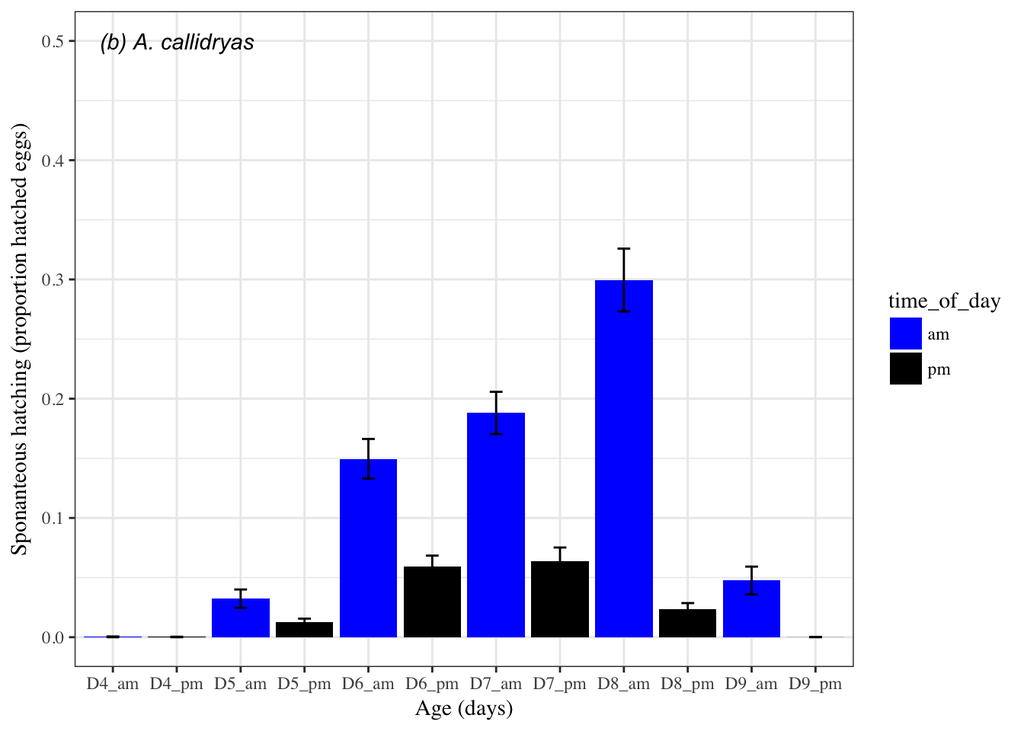

```r
library(ggplot2)

gc= ggplot(data=mphc, aes(x=day_time, y=mean_prop)) + geom_bar(stat="identity", aes(fill=time_of_day)) #use barplots w/time of day filled w/color
gc= gc + geom_errorbar(aes(ymin=mean_prop-SE, ymax=mean_prop+SE), width=.2, position=position_dodge(.9), color="black") #add black error bars
gc= gc + labs(x= "Age (days)", y= "Sponanteous hatching (proportion hatched eggs)") #make labels for axis
gc= gc + theme_bw(base_size = 11, base_family = "Times") #make theme in Times New Roman and b/w
gc= gc + annotate("text", x = 2, y = 0.5, label = "(b) A. callidryas", fontface= "italic") #add italicized text to figure!
gc= gc + scale_fill_manual(values = c("blue", "black")) # change "fills" to blue for day and black for night
gc
```

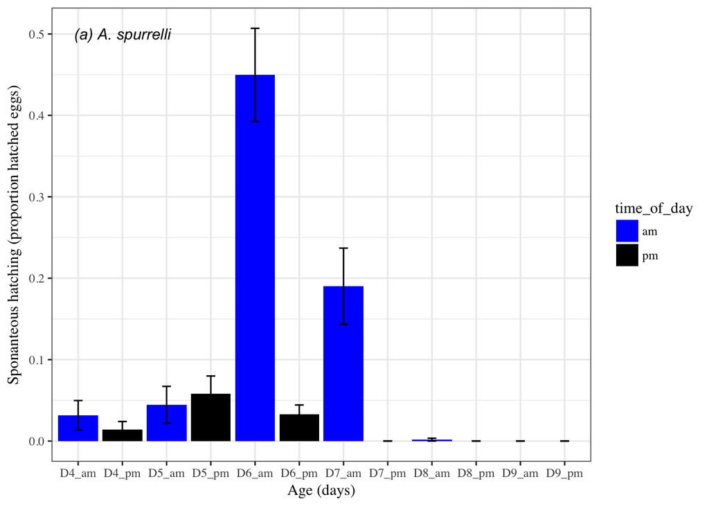

```r
#and again same for spurrelli
gs= ggplot(data=mphs, aes(x=day_time, y=mean_prop)) + geom_bar(stat="identity", aes(fill=time_of_day))
gs= gs + geom_errorbar(aes(ymin=mean_prop-SE, ymax=mean_prop+SE), width=.2, position=position_dodge(.9), color="black")
gs= gs + labs(x= "Age (days)", y= "Sponanteous hatching (proportion hatched eggs)")
gs= gs + theme_bw(base_size = 11, base_family = "Times")
gs= gs + annotate("text", x = 2, y = 0.5, label = "(a) A. spurrelli", fontface= "italic")
gs= gs + scale_fill_manual(values = c("blue", "black"))
gs
```

Just for fun, we could try putting on same plot somehow? maybe something like this? But Illustrator is best for these type of things!

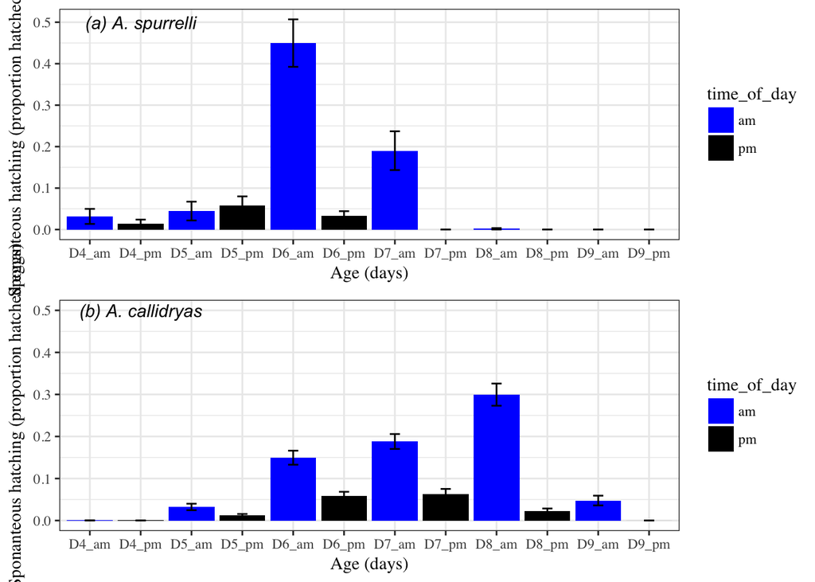

```r
library(grid)
grid.newpage()
grid.draw(rbind(ggplotGrob(gs), ggplotGrob(gc), size = "last"))
```

```r
# not too sure how to clean up the axis titles on this multiplot, but it gets the job done well enough...
```

We can take a look at the original figure and see how much better the R made one is! Better colors, better legends, and more information about the x axis. But overall, they are the same figures.

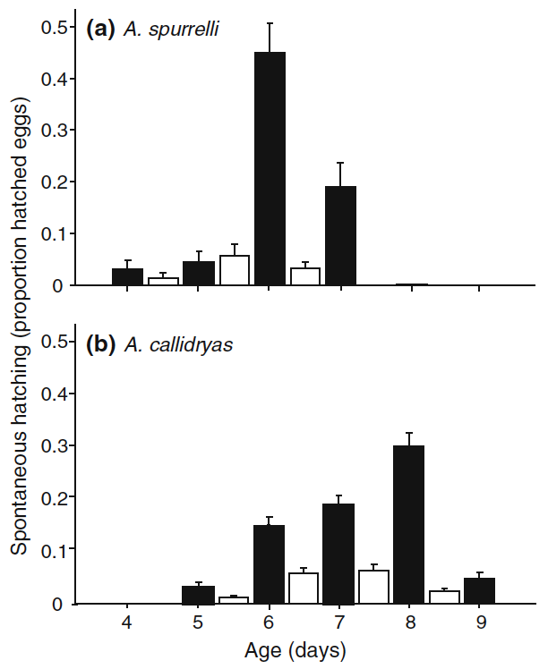

# Predation Experiments

## Read in data file

Next let’s load the data for the predation experiments!

```r
f <- curl("https://raw.githubusercontent.com/bguell/data-reanalysis-assignment/master/predation%20experiments.csv") #read in csv file from Github
d <- read.csv(f, header = TRUE, sep = ",", stringsAsFactors = FALSE)
head(d) #see data and column names
```

```
##   predation_type    species fish.size age initial survived survival_prop
## 1          snake callidryas        NA   5      15        9         0.600
## 2          snake callidryas        NA   5      39       30         0.769
## 3          snake callidryas        NA   5      52       31         0.596
## 4          snake callidryas        NA   5      35       19         0.543
## 5          snake callidryas        NA   5      27       15         0.556
## 6          snake callidryas        NA   5      33       20         0.606
```

This dataset is a compilation of the snake and fish predation experiments! We’ll have to subset data in order to only run models on each experiment and the predictors we chosse.Lets start with the snake predation experiment and data.

### Snake predation experiments

```r
library(lme4) #require package to fun GLMM
library(car) #require package to allow for Anova on GLMM and effects of predictors
library(dplyr)
```

#### Interactive effect of age and species

```r
#lets filter out only observations for snake predation experiments
dt = filter(d, predation_type =="snake")
dt
```

```
##    predation_type    species fish.size age initial survived survival_prop
## 1           snake callidryas        NA   5      15        9         0.600
## 2           snake callidryas        NA   5      39       30         0.769
## 3           snake callidryas        NA   5      52       31         0.596
## 4           snake callidryas        NA   5      35       19         0.543
## 5           snake callidryas        NA   5      27       15         0.556
## 6           snake callidryas        NA   5      33       20         0.606
## 7           snake callidryas        NA   5      34       17         0.500
## 8           snake callidryas        NA   5      32       20         0.625
## 9           snake callidryas        NA   5      31        8         0.258
## 10          snake callidryas        NA   5      34       32         0.941
## 11          snake callidryas        NA   6      25       18         0.720
## 12          snake callidryas        NA   6      45       39         0.867
## 13          snake callidryas        NA   6      43       36         0.837
## 14          snake callidryas        NA   6      53       43         0.811
```

[output cut: 36 more lines]

```r
m=glm(survival_prop~age*species, family = "binomial", weights = initial, data = dt)
summary(m)
```

```
##
## Call:
## glm(formula = survival_prop ~ age * species, family = "binomial",
##     data = dt, weights = initial)
##
## Deviance Residuals:
##     Min       1Q   Median       3Q      Max
## -4.5263  -1.6322  -0.4137   1.4767   3.9965
##
## Coefficients:
##                      Estimate Std. Error z value Pr(>|z|)
## (Intercept)          -1.50344    0.45667  -3.292 0.000994 ***
## age                   0.43021    0.07505   5.732 9.93e-09 ***
## speciesspurrelli     -7.59553    0.89613  -8.476  < 2e-16 ***
## age:speciesspurrelli  1.28924    0.17844   7.225 5.01e-13 ***
## ---
## Signif. codes:  0 '***' 0.001 '**' 0.01 '*' 0.05 '.' 0.1 ' ' 1
##
## (Dispersion parameter for binomial family taken to be 1)
##
##     Null deviance: 1011.02  on 49  degrees of freedom
## Residual deviance:  174.88  on 46  degrees of freedom
## AIC: 354.38
##
## Number of Fisher Scoring iterations: 5
```

```r
Anova(m)
```

```
## Analysis of Deviance Table (Type II tests)
##
## Response: survival_prop
##             LR Chisq Df Pr(>Chisq)
## age          113.739  1  < 2.2e-16 ***
## species       85.976  1  < 2.2e-16 ***
## age:species   57.386  1  3.582e-14 ***
## ---
## Signif. codes:  0 '***' 0.001 '**' 0.01 '*' 0.05 '.' 0.1 ' ' 1
```

#### Effect of age on callidryas escape success:

```r
dc = filter(d, predation_type =="snake")
dc = filter(dc, species=="callidryas")

m=glm(survival_prop~age, family = "binomial", weights = initial, data = dc)
summary(m)
```

```
##
## Call:
## glm(formula = survival_prop ~ age, family = "binomial", data = dc,
##     weights = initial)
##
## Deviance Residuals:
##     Min       1Q   Median       3Q      Max
## -4.5263  -1.2429  -0.3125   1.4767   3.9965
##
## Coefficients:
##             Estimate Std. Error z value Pr(>|z|)
## (Intercept) -1.50344    0.45667  -3.292 0.000994 ***
## age          0.43021    0.07505   5.732 9.93e-09 ***
## ---
## Signif. codes:  0 '***' 0.001 '**' 0.01 '*' 0.05 '.' 0.1 ' ' 1
##
## (Dispersion parameter for binomial family taken to be 1)
##
##     Null deviance: 134.43  on 33  degrees of freedom
## Residual deviance:  99.77  on 32  degrees of freedom
## AIC: 224.48
##
## Number of Fisher Scoring iterations: 4
```

```r
Anova(m)
```

```
## Analysis of Deviance Table (Type II tests)
##
## Response: survival_prop
##     LR Chisq Df Pr(>Chisq)
## age   34.655  1  3.937e-09 ***
## ---
## Signif. codes:  0 '***' 0.001 '**' 0.01 '*' 0.05 '.' 0.1 ' ' 1
```

```r
ds = filter(d, predation_type =="snake")
ds = filter(d, species=="spurrelli")

m=glm(survival_prop~age, family = "binomial", weights = initial, data = ds)
summary(m)
```

```
##
## Call:
## glm(formula = survival_prop ~ age, family = "binomial", data = ds,
##     weights = initial)
##
## Deviance Residuals:
##     Min       1Q   Median       3Q      Max
## -4.9836  -2.4314  -0.9558   0.2057   4.9301
##
## Coefficients:
##             Estimate Std. Error z value Pr(>|z|)
## (Intercept)  -4.9424     0.4178 -11.829   <2e-16 ***
## age           0.8070     0.0850   9.495   <2e-16 ***
## ---
## Signif. codes:  0 '***' 0.001 '**' 0.01 '*' 0.05 '.' 0.1 ' ' 1
##
## (Dispersion parameter for binomial family taken to be 1)
##
##     Null deviance: 253.57  on 27  degrees of freedom
## Residual deviance: 155.56  on 26  degrees of freedom
## AIC: 237.95
##
## Number of Fisher Scoring iterations: 4
```

```r
Anova(m)
```

```
## Analysis of Deviance Table (Type II tests)
##
## Response: survival_prop
##     LR Chisq Df Pr(>Chisq)
## age   98.005  1  < 2.2e-16 ***
## ---
## Signif. codes:  0 '***' 0.001 '**' 0.01 '*' 0.05 '.' 0.1 ' ' 1
```